# Rule extraction - experiments new paper

# Incorporating T2w breast MRI in CADx of breast lesions:

## Overall aim:

To investigate whether we can obtain an increase in discrimination ability for the classification task of cancerous and non-cancerous lesions using T2w imaging derived features in addition to more conventional T1w CE-MRI based-features

After running 10 folds of cross-validation (cv), below is the AUC distributions achieved on held-out test sets:

```
   Min. 1st Qu.  Median    Mean 3rd Qu.    Max.
 0.7600  0.7899  0.8083  0.8088  0.8177  0.8879
```

```
   Min. 1st Qu.  Median    Mean 3rd Qu.    Max.
 0.7200  0.7871  0.8188  0.8182  0.8500  0.9010
```

```
   Min. 1st Qu.  Median    Mean 3rd Qu.    Max.
 0.7829  0.7913  0.8103  0.8247  0.8448  0.9394
```

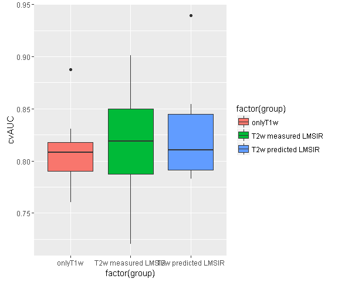

## Performance of combined T1w+T2w vs. only T1w classifiers

### in all lesions (pooled data across cv-folds and plot pooled results)

```
[1] "Results for T1w-only features classifier:"
```

```
Area under the curve: 0.8014
95% CI (2000 stratified bootstrap replicates):
 thresholds sp.low sp.median sp.high se.low se.median se.high
  0.4706139 0.6041    0.6653  0.7224 0.7696    0.8089  0.8482
```

```
[1] "Results for T2w measured LMSIR features classifier:"
```

```
Area under the curve: 0.8149
95% CI (2000 stratified bootstrap replicates):
 thresholds sp.low sp.median sp.high se.low se.median se.high
  0.4040565 0.7469       0.8   0.849 0.6518    0.6963  0.7408
```

```
[1] "Results for T2w predicted LMSIR features classifier:"
```

```
Area under the curve: 0.828
95% CI (2000 stratified bootstrap replicates):
 thresholds sp.low sp.median sp.high se.low se.median se.high
   0.409482 0.6776    0.7347  0.7918 0.7304    0.7723  0.8141
```

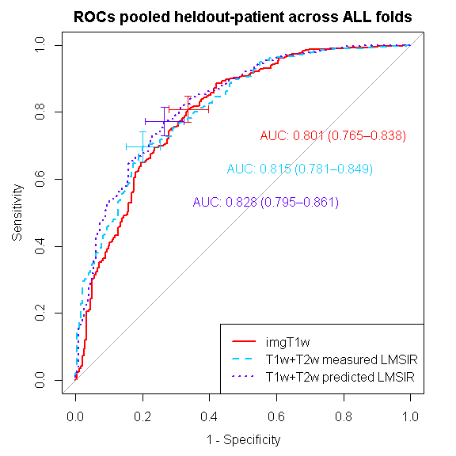

### Significance t-test and Effect size:

Power analysis is an important aspect of experimental design. It allows us to determine the sample size required to detect an effect of a given size with a given degree of confidence. Conversely, it allows us to determine the probability of detecting an effect of a given size with a given level of confidence, under sample size constraints. If the probability is unacceptably low, we would be wise to alter or abandon the experiment.

The following four quantities have an intimate relationship: 1. sample size 2. effect size 3. significance level = P(Type I error) = probability of finding an effect that is not there 4. power = 1 - P(Type II error) = probability of finding an effect that is there

Given any three, we can determine the fourth.

Cohen (1988) hesitantly defined effect sizes as “small,d = .2,” “medium,d = .5,” and “large,d =.8”, stating that “there is a certain risk in inherent in offering conventional operational definitions for those terms for use in power analysis in as diverse a field of inquiry as behavioral science” (p. 25).

Effect sizes can also be thought of as the average percentile standing of the average treated (or experimental) participant relative to the average untreated (or control) participant. An ES of 0.0 indicates that the mean of thetreated group is at the 50 thpercentile of the untreated group. An ES of 0.8 indicates that the mean of the treated group is at the 79th percentile of the untreated group. An effect size of 1.7 indicates that the mean of thetreated group is at the 95.5 percentile of the untreated group.

```
    Bootstrap test for two correlated ROC curves

data:  p2mLMSIR$ROC and p1all$ROC
D = 0.92937, boot.n = 2000, boot.stratified = 1, p-value = 0.1763
alternative hypothesis: true difference in AUC is greater than 0
sample estimates:
AUC of roc1 AUC of roc2
  0.8149054   0.8013730
```

```
    Bootstrap test for two correlated ROC curves

data:  p2pLMSIR$ROC and p1all$ROC
D = 2.0863, boot.n = 2000, boot.stratified = 1, p-value = 0.01848
alternative hypothesis: true difference in AUC is greater than 0
sample estimates:
AUC of roc1 AUC of roc2
  0.8280158   0.8013730
```

```
    Bootstrap test for two correlated ROC curves

data:  p2mLMSIR$ROC and p2pLMSIR$ROC
D = -1.0196, boot.n = 2000, boot.stratified = 1, p-value = 0.3079
alternative hypothesis: true difference in AUC is not equal to 0
sample estimates:
AUC of roc1 AUC of roc2
  0.8149054   0.8280158
```

```
     Two-sample t test power calculation

              n = 245
              d = 0.1617076
      sig.level = 0.1805556
          power = 0.6741573
    alternative = two.sided

NOTE: n is number in *each* group
```

#### Aim Experiment 4: Rule extraction and likelihood ratios of T1w vs. T2w diagnostic predictions

```
============ rule gbm trees imgT2pLMSIR
Stochastic Gradient Boosting

549 samples
221 predictors
  2 classes: 'C', 'NC'

No pre-processing
Resampling: Cross-Validated (10 fold)
Summary of sample sizes: 494, 494, 494, 495, 494, 494, ...
Resampling results across tuning parameters:

  interaction.depth  n.trees  ROC        Sens       Spec
  2                  1000     0.8123492  0.5963203  0.8401070
  2                  1500     0.8143420  0.6054113  0.8370766
  2                  2000     0.8149590  0.6192641  0.8429590
  3                  1000     0.8146532  0.6008658  0.8521390
  3                  1500     0.8165826  0.6194805  0.8369875
  3                  2000     0.8197803  0.6333333  0.8369875
  4                  1000     0.8166144  0.5969697  0.8612299
  4                  1500     0.8211901  0.6426407  0.8430481
  4                  2000     0.8236230  0.6290043  0.8429590
  6                  1000     0.8215544  0.6103896  0.8581105
  6                  1500     0.8215125  0.6194805  0.8520499
  6                  2000     0.8230377  0.6238095  0.8551693

Tuning parameter 'shrinkage' was held constant at a value of 0.01
Tuning parameter
 'n.minobsinnode' was held constant at a value of 10
ROC was used to select the optimal model using  the largest value.
The final values used for the model were n.trees = 2000, interaction.depth = 4, shrinkage =
 0.01 and n.minobsinnode = 10.
   shrinkage interaction.depth n.minobsinnode n.trees       ROC      Sens      Spec      ROCSD
1       0.01                 2             10    1000 0.8123492 0.5963203 0.8401070 0.08250904
4       0.01                 3             10    1000 0.8146532 0.6008658 0.8521390 0.08141301
7       0.01                 4             10    1000 0.8166144 0.5969697 0.8612299 0.08700230
10      0.01                 6             10    1000 0.8215544 0.6103896 0.8581105 0.08304086
2       0.01                 2             10    1500 0.8143420 0.6054113 0.8370766 0.07866763
5       0.01                 3             10    1500 0.8165826 0.6194805 0.8369875 0.07895563
8       0.01                 4             10    1500 0.8211901 0.6426407 0.8430481 0.08592654
```

[output cut: 196 more lines]

```
[1] "test complies with # rules: 15 out of 112"
[1] "test complies with # rules: 9 out of 112"
     len freq   err
7086   3 0.04 0.091
                                                                                               condition
7086 max_RGH_var<=0.0830499307748255 & V9<=3.5187690383568 & T2texture_variance_nondir<=325.568685326362
     pred                            prob sumtempProb
7086   NC 0.5486425, 0.6723696, 0.4721203   0.5643775
[1] "test complies with # rules: 11 out of 112"
     len  freq   err
8608   3 0.062 0.088
                                                                                   condition pred
8608 dce2SE14>0.432624096558318 & dce3SE13<=0.660588526384995 & T2_lesionSI>43.1284281668948   NC
                                prob sumtempProb
8608 0.4585595, 0.4432739, 0.4748801   0.4589045
```

```
Area under the curve: 0.76
95% CI (2000 stratified bootstrap replicates):
 thresholds sp.low sp.median sp.high se.low se.median se.high
  0.4500341   0.48      0.68    0.84 0.6286    0.7714  0.9143
```

```
Area under the curve: 0.72
95% CI (2000 stratified bootstrap replicates):
 thresholds sp.low sp.median sp.high se.low se.median se.high
  0.3870426   0.64       0.8    0.96 0.5421    0.6857  0.8286
```

```
Area under the curve: 0.7829
95% CI (2000 stratified bootstrap replicates):
 thresholds sp.low sp.median sp.high se.low se.median se.high
  0.3974667  0.599      0.76    0.92    0.6    0.7429  0.8857
```

```
Area under the curve: 0.6629
95% CI (2000 stratified bootstrap replicates):
 thresholds sp.low sp.median sp.high se.low se.median se.high
  0.5340025    0.2      0.36    0.56 0.8286    0.9143       1
```

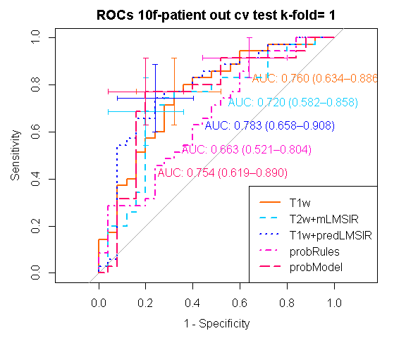

```
Area under the curve: 0.7543
95% CI (2000 stratified bootstrap replicates):
 thresholds sp.low sp.median sp.high se.low se.median se.high
  0.2795234   0.64       0.8    0.96 0.6286    0.7714  0.9143

============ rule gbm trees imgT2pLMSIR
Stochastic Gradient Boosting

540 samples
221 predictors
  2 classes: 'C', 'NC'

No pre-processing
Resampling: Cross-Validated (10 fold)
Summary of sample sizes: 485, 486, 486, 487, 485, 486, ...
```

[output cut: 192 more lines]

```
Area under the curve: 0.7976
95% CI (2000 stratified bootstrap replicates):
 thresholds sp.low sp.median sp.high se.low se.median se.high
  0.5053268 0.4516    0.6129  0.7742  0.925     0.975       1
```

```
Area under the curve: 0.8855
95% CI (2000 stratified bootstrap replicates):
 thresholds sp.low sp.median sp.high se.low se.median se.high
  0.4771523 0.5806    0.7419   0.871  0.775     0.875   0.975
```

```
Area under the curve: 0.8508
95% CI (2000 stratified bootstrap replicates):
 thresholds sp.low sp.median sp.high se.low se.median se.high
  0.4292579 0.5161    0.6774  0.8387  0.775     0.875   0.975
```

```
Area under the curve: 0.8081
95% CI (2000 stratified bootstrap replicates):
 thresholds sp.low sp.median sp.high se.low se.median se.high
  0.5114321 0.5806    0.7419   0.871  0.625      0.75   0.875
```

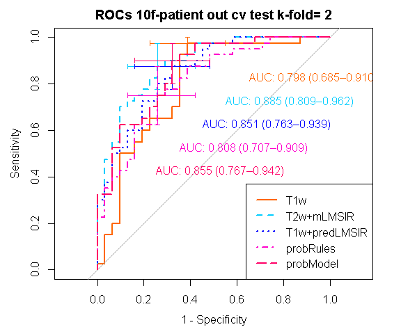

```
Area under the curve: 0.8548
95% CI (2000 stratified bootstrap replicates):
 thresholds sp.low sp.median sp.high se.low se.median se.high
  0.5067642 0.5161    0.6774  0.8387    0.8       0.9   0.975

============ rule gbm trees imgT2pLMSIR
Stochastic Gradient Boosting

553 samples
221 predictors
  2 classes: 'C', 'NC'

No pre-processing
Resampling: Cross-Validated (10 fold)
Summary of sample sizes: 497, 498, 499, 498, 498, 497, ...
```

[output cut: 162 more lines]

```
Area under the curve: 0.8121
95% CI (2000 stratified bootstrap replicates):
 thresholds sp.low sp.median sp.high se.low se.median se.high
  0.4912968 0.4737    0.6842  0.8947 0.6944    0.8333  0.9444
```

```
Area under the curve: 0.8129
95% CI (2000 stratified bootstrap replicates):
 thresholds sp.low sp.median sp.high se.low se.median se.high
  0.5665428 0.3684    0.5789  0.7895 0.8611    0.9444       1
```

```
Area under the curve: 0.8026
95% CI (2000 stratified bootstrap replicates):
 thresholds sp.low sp.median sp.high se.low se.median se.high
  0.3918007 0.5789    0.7895  0.9474 0.6667    0.8056  0.9167
```

```
Area under the curve: 0.7164
95% CI (2000 stratified bootstrap replicates):
 thresholds sp.low sp.median sp.high se.low se.median se.high
  0.5252716 0.3684    0.5789  0.7895 0.6667    0.8056  0.9167
```

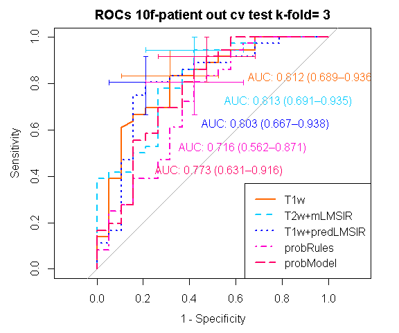

```
Area under the curve: 0.7734
95% CI (2000 stratified bootstrap replicates):
 thresholds sp.low sp.median sp.high se.low se.median se.high
  0.6399194 0.3158    0.5263  0.7368 0.8056    0.9167       1

============ rule gbm trees imgT2pLMSIR
Stochastic Gradient Boosting

555 samples
221 predictors
  2 classes: 'C', 'NC'

No pre-processing
Resampling: Cross-Validated (10 fold)
Summary of sample sizes: 500, 499, 500, 500, 499, 499, ...
Resampling results across tuning parameters:

  interaction.depth  n.trees  ROC        Sens       Spec
  2                  1000     0.8168825  0.5833333  0.8691622
  2                  1500     0.8189087  0.6108225  0.8602496
  2                  2000     0.8179746  0.6203463  0.8573975
  3                  1000     0.8185296  0.6017316  0.8691622
  3                  1500     0.8170660  0.6019481  0.8631016
  3                  2000     0.8184000  0.6067100  0.8661319
  4                  1000     0.8224084  0.5969697  0.8691622
  4                  1500     0.8227794  0.6203463  0.8749554
  4                  2000     0.8228176  0.6155844  0.8690731
  6                  1000     0.8229437  0.6108225  0.8721925
  6                  1500     0.8226810  0.6153680  0.8661319
  6                  2000     0.8239397  0.6292208  0.8690731

Tuning parameter 'shrinkage' was held constant at a value of 0.01
Tuning parameter
 'n.minobsinnode' was held constant at a value of 10
ROC was used to select the optimal model using  the largest value.
The final values used for the model were n.trees = 2000, interaction.depth = 6, shrinkage =
 0.01 and n.minobsinnode = 10.
   shrinkage interaction.depth n.minobsinnode n.trees       ROC      Sens      Spec      ROCSD
1       0.01                 2             10    1000 0.8168825 0.5833333 0.8691622 0.03598241
4       0.01                 3             10    1000 0.8185296 0.6017316 0.8691622 0.03326726
```

[output cut: 163 more lines]

```
1427   4 0.032 0.111
                                                                                                                                                                              condition
1427 irregularity<=0.984668990886858 & texture_variance_nondir_post1>191.786000082219 & T2texture_correlation_nondir>0.263972379118135 & T2texture_correlation_nondir>0.361597155528048
     pred                                       prob sumtempProb
1427    C 0.4937985, 0.4742500, 0.4468187, 0.5846211   0.4998721
[1] "test complies with # rules: 19 out of 187"
[1] "test complies with # rules: 14 out of 187"
[1] "test complies with # rules: 11 out of 187"
[1] "test complies with # rules: 2000 out of 187"
      len  freq   err                                                      condition pred
13176   2 0.032 0.111 max_RGH_mean<=0.495991412376266 & T2_lesionSI>113.683860342556   NC
                      prob sumtempProb
13176 0.5332697, 0.3199769   0.4266233
[1] "test complies with # rules: 9 out of 187"
[1] "test complies with # rules: 2000 out of 187"
```

```
Area under the curve: 0.8167
95% CI (2000 stratified bootstrap replicates):
 thresholds sp.low sp.median sp.high se.low se.median se.high
  0.4064521  0.625    0.7917  0.9583 0.5333       0.7  0.8667
```

```
Area under the curve: 0.85
95% CI (2000 stratified bootstrap replicates):
 thresholds sp.low sp.median sp.high se.low se.median se.high
  0.3199375  0.875    0.9583       1    0.5    0.6667  0.8333
```

```
Area under the curve: 0.8181
95% CI (2000 stratified bootstrap replicates):
 thresholds sp.low sp.median sp.high se.low se.median se.high
  0.5001467 0.3333    0.5417    0.75 0.8333    0.9333  1.0000
  0.3260255 0.7500    0.8750    1.00 0.4333    0.6000  0.7667
```

```
Area under the curve: 0.5861
95% CI (2000 stratified bootstrap replicates):
 thresholds sp.low sp.median sp.high se.low se.median se.high
  0.5068191  0.375    0.5833    0.75    0.5    0.6667  0.8333
```

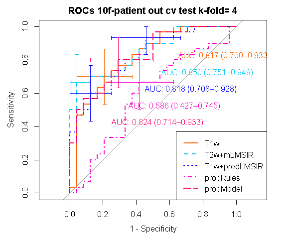

```
Area under the curve: 0.8236
95% CI (2000 stratified bootstrap replicates):
 thresholds sp.low sp.median sp.high se.low se.median se.high
  0.1913509    0.5    0.7083   0.875 0.6333       0.8  0.9333

============ rule gbm trees imgT2pLMSIR
Stochastic Gradient Boosting

550 samples
221 predictors
  2 classes: 'C', 'NC'

No pre-processing
Resampling: Cross-Validated (10 fold)
Summary of sample sizes: 495, 494, 495, 496, 494, 495, ...
Resampling results across tuning parameters:

  interaction.depth  n.trees  ROC        Sens       Spec
  2                  1000     0.8117956  0.5660173  0.8679144
  2                  1500     0.8082400  0.5889610  0.8559715
  2                  2000     0.8053979  0.6073593  0.8588235
  3                  1000     0.8153983  0.5935065  0.8588235
  3                  1500     0.8116854  0.6121212  0.8498217
  3                  2000     0.8114499  0.6025974  0.8590018
  4                  1000     0.8128471  0.5935065  0.8557041
  4                  1500     0.8114896  0.6073593  0.8617647
  4                  2000     0.8094669  0.6162338  0.8468806
  6                  1000     0.8138885  0.5841991  0.8589127
  6                  1500     0.8101564  0.5935065  0.8589127
  6                  2000     0.8090940  0.6073593  0.8588235

Tuning parameter 'shrinkage' was held constant at a value of 0.01
Tuning parameter
 'n.minobsinnode' was held constant at a value of 10
ROC was used to select the optimal model using  the largest value.
The final values used for the model were n.trees = 1000, interaction.depth = 3, shrinkage =
 0.01 and n.minobsinnode = 10.
   shrinkage interaction.depth n.minobsinnode n.trees       ROC      Sens      Spec      ROCSD
1       0.01                 2             10    1000 0.8117956 0.5660173 0.8679144 0.06865282
4       0.01                 3             10    1000 0.8153983 0.5935065 0.8588235 0.06969911
```

[output cut: 186 more lines]

```
[1] "test complies with # rules: 1000 out of 25"
[1] "test complies with # rules: 6 out of 25"
[1] "test complies with # rules: 1000 out of 25"
     len  freq   err                                                    condition pred
2043   2 0.202 0.189 Tpeak_countor>12.0617409688816 & T2RGH_var<=370.226486471733   NC
                     prob sumtempProb
2043 0.3730531, 0.5089100   0.4409815
[1] "test complies with # rules: 1000 out of 25"
     len  freq   err
3718   3 0.135 0.189
                                                                                                                           condition
3718 Vr_increasingRate_countor<=0.113820610943595 & texture_sumaverage_nondir_post2<=223.35047590633 & T2skew_F_r_i>1.21484263542727
     pred                            prob sumtempProb
3718   NC 0.5761680, 0.6450753, 0.5418709   0.5877047
[1] "test complies with # rules: 1000 out of 25"
```

```
Area under the curve: 0.8044
95% CI (2000 stratified bootstrap replicates):
 thresholds sp.low sp.median sp.high se.low se.median se.high
  0.4215601 0.7037    0.8519   0.963 0.4062    0.5938    0.75
```

```
Area under the curve: 0.7616
95% CI (2000 stratified bootstrap replicates):
 thresholds sp.low sp.median sp.high se.low se.median se.high
  0.4408423 0.4444    0.6296  0.8148  0.625    0.7812  0.9062
```

```
Area under the curve: 0.7894
95% CI (2000 stratified bootstrap replicates):
 thresholds sp.low sp.median sp.high se.low se.median se.high
  0.4635855 0.4815    0.6667  0.8148   0.75     0.875  0.9688
```

```
Area under the curve: 0.7755
95% CI (2000 stratified bootstrap replicates):
 thresholds sp.low sp.median sp.high se.low se.median se.high
  0.4964488 0.7778    0.8889       1 0.5312    0.6875  0.8438
```

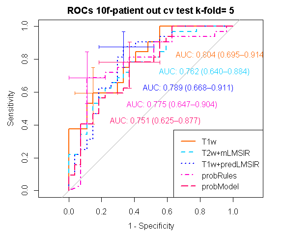

```
Area under the curve: 0.7512
95% CI (2000 stratified bootstrap replicates):
 thresholds sp.low sp.median sp.high se.low se.median se.high
  0.3403943 0.4444    0.6296  0.8148  0.625    0.7812  0.9062

============ rule gbm trees imgT2pLMSIR
Stochastic Gradient Boosting

546 samples
221 predictors
  2 classes: 'C', 'NC'

No pre-processing
Resampling: Cross-Validated (10 fold)
Summary of sample sizes: 491, 491, 492, 490, 492, 492, ...
Resampling results across tuning parameters:

  interaction.depth  n.trees  ROC        Sens       Spec
  2                  1000     0.8203492  0.6003953  0.8543561
  2                  1500     0.8224179  0.6233202  0.8421402
  2                  2000     0.8258472  0.6187747  0.8357955
  3                  1000     0.8272177  0.6007905  0.8420455
  3                  1500     0.8284405  0.6053360  0.8482955
  3                  2000     0.8292103  0.6189723  0.8420455
  4                  1000     0.8251213  0.6142292  0.8606061
  4                  1500     0.8254535  0.6096838  0.8482008
  4                  2000     0.8248304  0.6187747  0.8389205
  6                  1000     0.8248392  0.5871542  0.8420455
  6                  1500     0.8240648  0.6142292  0.8327652
  6                  2000     0.8262342  0.6144269  0.8357008

Tuning parameter 'shrinkage' was held constant at a value of 0.01
Tuning parameter
 'n.minobsinnode' was held constant at a value of 10
ROC was used to select the optimal model using  the largest value.
The final values used for the model were n.trees = 2000, interaction.depth = 3, shrinkage =
 0.01 and n.minobsinnode = 10.
   shrinkage interaction.depth n.minobsinnode n.trees       ROC      Sens      Spec      ROCSD
1       0.01                 2             10    1000 0.8203492 0.6003953 0.8543561 0.07031925
4       0.01                 3             10    1000 0.8272177 0.6007905 0.8420455 0.06030782
```

[output cut: 198 more lines]

```
2499 texture_sumaverage_nondir_post1>131.395713357342 & V10<=3.29645166883552 & T2_lesionSI>43.6236326923077
     pred                            prob sumtempProb
2499   NC 0.4583520, 0.4879422, 0.4728997   0.4730646
[1] "test complies with # rules: 1798 out of 43"
[1] "test complies with # rules: 2000 out of 43"
[1] "test complies with # rules: 1664 out of 43"
[1] "test complies with # rules: 5 out of 43"
[1] "test complies with # rules: 2000 out of 43"
[1] "test complies with # rules: 2000 out of 43"
     len  freq   err
5631   3 0.125 0.162
                                                                                                condition
5631 min_F_r_i>386.5 & texture_sumvariance_nondir_post2<=1048.75233234583 & T2kurt_F_r_i>1.14883296665627
     pred                            prob sumtempProb
5631   NC 0.5786830, 0.4887894, 0.4385449   0.5020058
```

```
Area under the curve: 0.8181
95% CI (2000 stratified bootstrap replicates):
 thresholds sp.low sp.median sp.high se.low se.median se.high
  0.4406966    0.7      0.85       1 0.5957    0.7234  0.8511
```

```
Area under the curve: 0.85
95% CI (2000 stratified bootstrap replicates):
 thresholds sp.low sp.median sp.high se.low se.median se.high
  0.3014082   0.85      0.95       1 0.5314    0.6596  0.7872
```

```
Area under the curve: 0.8266
95% CI (2000 stratified bootstrap replicates):
 thresholds sp.low sp.median sp.high se.low se.median se.high
  0.4370225   0.55      0.75    0.95  0.617    0.7447  0.8511
```

```
Area under the curve: 0.5553
95% CI (2000 stratified bootstrap replicates):
 thresholds sp.low sp.median sp.high se.low se.median se.high
  0.5177135   0.35      0.55    0.75 0.4468    0.5957  0.7447
```

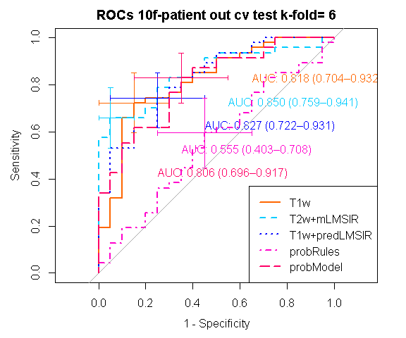

```
Area under the curve: 0.8064
95% CI (2000 stratified bootstrap replicates):
 thresholds sp.low sp.median sp.high se.low se.median se.high
  0.5713629   0.45      0.65    0.85 0.7234    0.8298  0.9362

============ rule gbm trees imgT2pLMSIR
Stochastic Gradient Boosting

548 samples
221 predictors
  2 classes: 'C', 'NC'

No pre-processing
Resampling: Cross-Validated (10 fold)
Summary of sample sizes: 494, 493, 493, 493, 493, 493, ...
```

[output cut: 172 more lines]

```
Area under the curve: 0.7874
95% CI (2000 stratified bootstrap replicates):
 thresholds sp.low sp.median sp.high se.low se.median se.high
  0.5251699 0.3333    0.5417    0.75 0.8718    0.9487       1
```

```
Area under the curve: 0.7863
95% CI (2000 stratified bootstrap replicates):
 thresholds sp.low sp.median sp.high se.low se.median se.high
  0.3986131 0.5833      0.75  0.9167  0.641    0.7692  0.8974
```

```
Area under the curve: 0.797
95% CI (2000 stratified bootstrap replicates):
 thresholds sp.low sp.median sp.high se.low se.median se.high
  0.3684782 0.7083    0.8333  0.9583 0.5128    0.6667  0.8205
```

```
Area under the curve: 0.8056
95% CI (2000 stratified bootstrap replicates):
 thresholds sp.low sp.median sp.high se.low se.median se.high
  0.5238473 0.4583    0.6667  0.8333 0.8205    0.9231       1
```

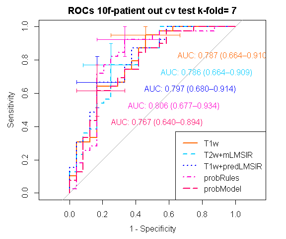

```
Area under the curve: 0.7671
95% CI (2000 stratified bootstrap replicates):
 thresholds sp.low sp.median sp.high se.low se.median se.high
  0.0171481 0.6667    0.8333  0.9583 0.4615    0.6154  0.7692

============ rule gbm trees imgT2pLMSIR
Stochastic Gradient Boosting

544 samples
221 predictors
  2 classes: 'C', 'NC'

No pre-processing
Resampling: Cross-Validated (10 fold)
Summary of sample sizes: 491, 490, 490, 489, 491, 489, ...
Resampling results across tuning parameters:

  interaction.depth  n.trees  ROC        Sens       Spec
  2                  1000     0.8127091  0.6049784  0.8623106
  2                  1500     0.8131961  0.5956710  0.8714015
  2                  2000     0.8130989  0.6047619  0.8560606
  3                  1000     0.8149019  0.6004329  0.8652462
  3                  1500     0.8151835  0.5822511  0.8590909
  3                  2000     0.8175048  0.5958874  0.8468750
  4                  1000     0.8159337  0.5822511  0.8714015
  4                  1500     0.8185151  0.5774892  0.8681818
  4                  2000     0.8181541  0.5958874  0.8469697
  6                  1000     0.8215952  0.5774892  0.8743371
  6                  1500     0.8212755  0.5820346  0.8621212
  6                  2000     0.8239583  0.5863636  0.8590909

Tuning parameter 'shrinkage' was held constant at a value of 0.01
Tuning parameter
 'n.minobsinnode' was held constant at a value of 10
ROC was used to select the optimal model using  the largest value.
The final values used for the model were n.trees = 2000, interaction.depth = 6, shrinkage =
 0.01 and n.minobsinnode = 10.
   shrinkage interaction.depth n.minobsinnode n.trees       ROC      Sens      Spec      ROCSD
1       0.01                 2             10    1000 0.8127091 0.6049784 0.8623106 0.05337614
4       0.01                 3             10    1000 0.8149019 0.6004329 0.8652462 0.04693579
```

[output cut: 184 more lines]

```
8358    C 0.4192649, 0.5621379, 0.5517737, 0.6701021, 0.4812520   0.5369061
[1] "test complies with # rules: 13 out of 168"
[1] "test complies with # rules: 9 out of 168"
[1] "test complies with # rules: 14 out of 168"
[1] "test complies with # rules: 26 out of 168"
[1] "test complies with # rules: 11 out of 168"
     len  freq   err
5842   3 0.066 0.083
                                                                                                                       condition
5842 ivVariance<=0.0375174805963147 & T2texture_entropy_nondir<=3.48878658358655 & T2texture_diffentropy_nondir>1.70774926189513
     pred                            prob sumtempProb
5842   NC 0.4992823, 0.5380998, 0.4868618   0.5080813
[1] "test complies with # rules: 2000 out of 168"
[1] "test complies with # rules: 5 out of 168"
[1] "test complies with # rules: 6 out of 168"
```

```
Area under the curve: 0.8305
95% CI (2000 stratified bootstrap replicates):
 thresholds sp.low sp.median sp.high se.low se.median se.high
  0.4711738   0.52      0.72    0.88 0.7143    0.8333  0.9286
```

```
Area under the curve: 0.8248
95% CI (2000 stratified bootstrap replicates):
 thresholds sp.low sp.median sp.high se.low se.median se.high
  0.4113339    0.8      0.92       1 0.4524     0.619  0.7619
```

```
Area under the curve: 0.8543
95% CI (2000 stratified bootstrap replicates):
 thresholds sp.low sp.median sp.high se.low se.median se.high
  0.4115153   0.68      0.84    0.96 0.5952    0.7381   0.881
```

```
Area under the curve: 0.6905
95% CI (2000 stratified bootstrap replicates):
 thresholds sp.low sp.median sp.high se.low se.median se.high
  0.4938438   0.52      0.72    0.88 0.4762     0.619  0.7619
```

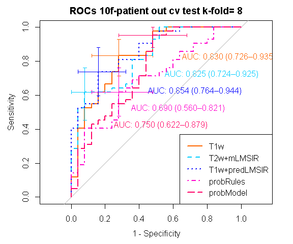

```
Area under the curve: 0.7505
95% CI (2000 stratified bootstrap replicates):
 thresholds sp.low sp.median sp.high se.low se.median se.high
  0.5408004   0.32      0.52    0.72  0.881    0.9524       1

============ rule gbm trees imgT2pLMSIR
Stochastic Gradient Boosting

541 samples
221 predictors
  2 classes: 'C', 'NC'

No pre-processing
Resampling: Cross-Validated (10 fold)
Summary of sample sizes: 487, 487, 487, 488, 487, 487, ...
Resampling results across tuning parameters:

  interaction.depth  n.trees  ROC        Sens       Spec
  2                  1000     0.8193228  0.6339921  0.8550403
  2                  1500     0.8227584  0.6517787  0.8517137
  2                  2000     0.8280975  0.6654150  0.8454637
  3                  1000     0.8283940  0.6385375  0.8613911
  3                  1500     0.8324830  0.6519763  0.8675403
  3                  2000     0.8345553  0.6519763  0.8612903
  4                  1000     0.8309932  0.6298419  0.8610887
  4                  1500     0.8349484  0.6385375  0.8643145
  4                  2000     0.8409960  0.6383399  0.8643145
  6                  1000     0.8290135  0.6296443  0.8737903
  6                  1500     0.8328231  0.6298419  0.8706653
  6                  2000     0.8334825  0.6341897  0.8644153

Tuning parameter 'shrinkage' was held constant at a value of 0.01
Tuning parameter
 'n.minobsinnode' was held constant at a value of 10
ROC was used to select the optimal model using  the largest value.
The final values used for the model were n.trees = 2000, interaction.depth = 4, shrinkage =
 0.01 and n.minobsinnode = 10.
   shrinkage interaction.depth n.minobsinnode n.trees       ROC      Sens      Spec      ROCSD
1       0.01                 2             10    1000 0.8193228 0.6339921 0.8550403 0.07752424
4       0.01                 3             10    1000 0.8283940 0.6385375 0.8613911 0.07918200
```

[output cut: 195 more lines]

```
[1] "test complies with # rules: 2000 out of 47"
     len  freq   err
1153   3 0.207 0.125
                                                                                                          condition
1153 Tpeak_inside>7.90722296680836 & texture_energy_nondir_post4<=0.00618966000712137 & T2RGH_var<=349.491222787327
     pred                            prob sumtempProb
1153   NC 0.4795554, 0.3563718, 0.3132517   0.3830596
[1] "test complies with # rules: 2000 out of 47"
     len  freq   err
4294   4 0.109 0.119
                                                                                                                                 condition
4294 Tpeak_inside>2.54133465388862 & iiMin_change_Variance_uptake>0.395737622135059 & V17<=25.4632748734924 & T2_lesionSI>52.9125674273991
     pred                                       prob sumtempProb
4294   NC 0.4237933, 0.5097312, 0.4460827, 0.4451928      0.4562
[1] "test complies with # rules: 2000 out of 47"
```

```
Area under the curve: 0.7729
95% CI (2000 stratified bootstrap replicates):
 thresholds sp.low sp.median sp.high se.low se.median se.high
  0.5067831    0.5       0.7     0.9 0.6875    0.8125  0.9167
```

```
Area under the curve: 0.7896
95% CI (2000 stratified bootstrap replicates):
 thresholds sp.low sp.median sp.high se.low se.median se.high
  0.4316145   0.55      0.75    0.95 0.6458    0.7708   0.875
```

```
Area under the curve: 0.7865
95% CI (2000 stratified bootstrap replicates):
 thresholds sp.low sp.median sp.high se.low se.median se.high
  0.3746715    0.6       0.8    0.95 0.5833    0.7083  0.8333
```

```
Area under the curve: 0.6865
95% CI (2000 stratified bootstrap replicates):
 thresholds sp.low sp.median sp.high se.low se.median se.high
  0.5035049   0.55      0.75     0.9 0.5833    0.7083  0.8333
```

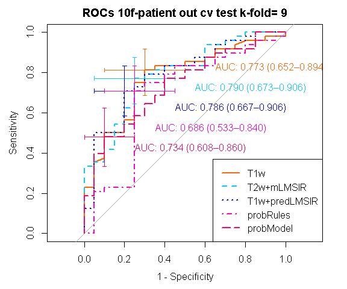

```
Area under the curve: 0.7344
95% CI (2000 stratified bootstrap replicates):
 thresholds sp.low sp.median sp.high se.low se.median se.high
 0.05547199   0.75       0.9       1 0.3333    0.4792   0.625

============ rule gbm trees imgT2pLMSIR
Stochastic Gradient Boosting

546 samples
221 predictors
  2 classes: 'C', 'NC'

No pre-processing
Resampling: Cross-Validated (10 fold)
Summary of sample sizes: 491, 491, 492, 492, 492, 492, ...
Resampling results across tuning parameters:

  interaction.depth  n.trees  ROC        Sens       Spec
  2                  1000     0.7985474  0.5586580  0.8557932
  2                  1500     0.8041488  0.5725108  0.8557041
  2                  2000     0.8040003  0.5915584  0.8467023
  3                  1000     0.8037888  0.5636364  0.8679144
  3                  1500     0.8050563  0.5822511  0.8616756
  3                  2000     0.8045717  0.5961039  0.8496435
  4                  1000     0.8131664  0.5634199  0.8738859
  4                  1500     0.8192131  0.5915584  0.8769162
  4                  2000     0.8175714  0.6097403  0.8617647
  6                  1000     0.8042125  0.5588745  0.8769162
  6                  1500     0.8082919  0.5727273  0.8527629
  6                  2000     0.8121606  0.6008658  0.8437611

Tuning parameter 'shrinkage' was held constant at a value of 0.01
Tuning parameter
 'n.minobsinnode' was held constant at a value of 10
ROC was used to select the optimal model using  the largest value.
The final values used for the model were n.trees = 1500, interaction.depth = 4, shrinkage =
 0.01 and n.minobsinnode = 10.
   shrinkage interaction.depth n.minobsinnode n.trees       ROC      Sens      Spec      ROCSD
1       0.01                 2             10    1000 0.7985474 0.5586580 0.8557932 0.03744263
4       0.01                 3             10    1000 0.8037888 0.5636364 0.8679144 0.04092713
```

[output cut: 204 more lines]

```
1976 0.5758153, 0.4910063, 0.5130602   0.5266273
[1] "test complies with # rules: 1500 out of 51"
[1] "test complies with # rules: 1500 out of 51"
[1] "test complies with # rules: 5 out of 51"
[1] "test complies with # rules: 1500 out of 51"
     len  freq   err
1462   3 0.048 0.115
                                                                                               condition
1462 peakVr_countor<=1.5 & mean_F_r_i>793.188105082232 & T2texture_correlation_nondir<=0.319617514478464
     pred                            prob sumtempProb
1462    C 0.4470454, 0.4989303, 0.6297145   0.5252301
[1] "test complies with # rules: 1500 out of 51"
[1] "test complies with # rules: 5 out of 51"
[1] "test complies with # rules: 1500 out of 51"
[1] "test complies with # rules: 1500 out of 51"
```

```
Area under the curve: 0.8879
95% CI (2000 stratified bootstrap replicates):
 thresholds sp.low sp.median sp.high se.low se.median se.high
   0.427195 0.6667       0.8  0.9333 0.7879    0.9091       1
```

```
Area under the curve: 0.901
95% CI (2000 stratified bootstrap replicates):
 thresholds sp.low sp.median sp.high se.low se.median se.high
  0.3753419 0.7333    0.8667  0.9667 0.7576    0.8788  0.9697
```

```
Area under the curve: 0.9394
95% CI (2000 stratified bootstrap replicates):
 thresholds sp.low sp.median sp.high se.low se.median se.high
  0.3675162 0.8333    0.9333       1 0.7576    0.8788  0.9697
```

```
Area under the curve: 0.7273
95% CI (2000 stratified bootstrap replicates):
 thresholds sp.low sp.median sp.high se.low se.median se.high
  0.5011773 0.6333       0.8  0.9333 0.4242    0.6061  0.7583
```

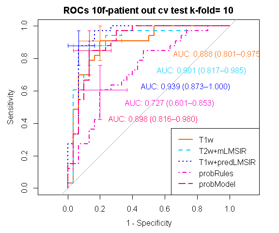

```
Area under the curve: 0.898
95% CI (2000 stratified bootstrap replicates):
 thresholds sp.low sp.median sp.high se.low se.median se.high
  0.1736443 0.7333    0.8667  0.9667  0.697    0.8485  0.9697
```

```r
# read k-fold-out
allrulesres = c()

for (k in 1:10) {
    # 1:10f cv
    load(paste0("Z:/Cristina/Section2/finalTreebased-boosting/Outputs/T2SIvspredLMSIR_boost_addeddiagvalue_cv",
        k, ".RData"))
    source("Z:/Cristina/Section2/finalTreebased-boosting/FunctionsRules.R")

    ################## Define datasets
    imgT1train = T1train[, -c(ncol(T1train))]
    imgT2train = T1T2train[, -c(ncol(T1T2train))]  #'T1w+T2wSI'
    imgT2mLMSIR = cbind(imgT2train[, -c(201, 223:242)], trainpredT2LMSIR[2])  #'T1w -T2wSI + measureLMSIR
    imgT2pLMSIR = cbind(imgT2train[, -c(201, 223:242)], trainpredT2LMSIR[1])  #'T1w+T2wSI_predictedLMSIR'

    # test set
    imgT1test = T1test[, -c(ncol(T1test))]
    T1T2test = allfT1T2[[2]][-c(201, 223:ncol(allfT1T2[[2]]))]
    imgT2mLMSIRtest = cbind(T1T2test, testpredT2LMSIR[2])
    imgT2pLMSIRtest = cbind(T1T2test, testpredT2LMSIR[1])
    classes = levels(imgT2pLMSIRtest[, "lesion_label"])

    # form feature dictionary
    fdict = feature_dictionary(imgT2pLMSIR)
    fnames = fdict$fnnames

    ############ Build a train trees check performance using 10-fold cross-validation
    cat("\n============ rule gbm trees imgT2pLMSIR \n")
    # train treees create grid of evaluation points
    gbmControl <- trainControl(method = "cv", number = 10, returnResamp = "final", savePredictions = "final",
        summaryFunction = twoClassSummary, classProbs = TRUE)

    # for tunned parameters
    gbmGrid = expand.grid(.n.trees = c(1000, 1500, 2000), .interaction.depth = c(2, 3, 4, 6), .shrinkage = c(0.01),
        .n.minobsinnode = c(10))

    # caret train cross-validated gbmModel, finalmodel has optimal parameters on training set
    imgT2pLMSIR = na.omit(imgT2pLMSIR)
    gbmModel <- train(lesion_label ~ ., data = imgT2pLMSIR, method = "gbm", distribution = "adaboost",
        trControl = gbmControl, tuneGrid = gbmGrid, verbose = FALSE, metric = "ROC")

    # predictions <- predict(object=gbmModel$, X, type='prob') summarize the model # plot the effect of
    # parameters on accuracy
    print(gbmModel)
    plot(gbmModel)
    print(gbmModel$results)

    # transform rf object to an inTrees' format
    X <- imgT2pLMSIR[, 2:(ncol(imgT2pLMSIR))]
    target <- imgT2pLMSIR[, "lesion_label"]
    treeList <- myGBM2List(gbmModel$finalModel, X)

    # extract rules
    myruleExec = myextractRules(treeList, X, ntree = gbmModel$finalModel$n.trees)
    ruleExec = myruleExec$ruleExec
    rules = myruleExec$rules
    rulesProb = myruleExec$rulesProb

    # how good are these rules or what classification we obtain by applying them.  This can be done with
    # the handy function getRuleMetric. For the first 10 extracted rules:
    ruleMetric <- mygetRuleMetric(rules, rulesProb, X, target, gbmModel)  # get rule metrics
    ruleMetric[1:10, ]

    # a matrix including the conditions, prediction, and metrics, ordered by priority.
    alearner <- ruleMetric
    restest = c()
    allselRulesIx = list()
    for (i in 1:nrow(imgT2pLMSIRtest)) {
        X = imgT2pLMSIRtest[i, 2:ncol(imgT2pLMSIRtest)]
        y = imgT2pLMSIRtest[i, "lesion_label"]
        rulesoutput = myapplyLearner(alearner, X, y, minerr = 0.1, minfrq = 10/627, classes, gbmModel)

        # collect top scoring rules
        allselRulesIx[[i]] = rulesoutput[[1]]
        restest = rbind(restest, rulesoutput[[2]])
    }

    # compare
    confusionMatrix(perf_T2wpLMSIR$pred, perf_T2wpLMSIR$obs)
    dfrestest = as.data.frame(restest, stringsAsFactors = FALSE)
    dfrestest$predRules = ifelse(dfrestest$probModel >= 0.5, "C", "NC")
    confusionMatrix(dfrestest$predRules, restest[, "obsR"])

    allrulesres = rbind(allrulesres, dfrestest)
    pander(allrulesres)

    # plot iter plot ROCs each pass individually in l-o-p heldout test cases
    par(mfrow = c(1, 1))
    n = 15
    colors = rainbow(n, s = 1, v = 1, start = 0, end = max(1, n - 1)/n, alpha = 1)
    # plot 1/4
    p1 = calcAUC_plot(perf_imgT1$obs, perf_imgT1$C, xptext = 0.35, yptext = 0.85, 1, colors[2], atitle = "")
    par(new = TRUE)
    p2 = calcAUC_plot(perf_T2wmLMSIR$obs, perf_T2wmLMSIR$C, xptext = 0.45, yptext = 0.75, 2, colors[9],
        atitle = "")
    par(new = TRUE)
    p3 = calcAUC_plot(perf_T2wpLMSIR$obs, perf_T2wpLMSIR$C, xptext = 0.55, yptext = 0.65, 3, colors[11],
        atitle = "")

    par(new = TRUE)
    p4 = calcAUC_plot(perf_T2wpLMSIR$obs, as.numeric(restest[, "probRules"]), xptext = 0.65, yptext = 0.55,
        4, colors[14], atitle = "")
    par(new = TRUE)
    p5 = calcAUC_plot(perf_T2wpLMSIR$obs, as.numeric(restest[, "probModel"]), xptext = 0.75, yptext = 0.45,
        5, colors[15], atitle = paste0("ROCs 10f-patient out cv test k-fold= ", k))

    legend("bottomright", legend = c(paste0("T1w"), paste0("T2w+mLMSIR"), paste0("T1w+predLMSIR"), paste0("probRules"),
        paste0("probModel")), col = c(colors[2], colors[9], colors[11], colors[14], colors[15]), lty = c(1,
        2, 3, 4, 5), lwd = 2)

    # save current state k patient out
    save.image(paste0("Outputs/gmbRule_noT2SIpredLMSIR_boost_addeddiagvalue_cv", k, ".RData"))
}
```

```r
# save current state k patient out
save.image("Outputs/STEL_noT2SIpredLMSIR_boost_addeddiagvalue.RData")
```

```r
confusionMatrix(allrulesres[, "predR"], allrulesres[, "obsR"])
```

```
Confusion Matrix and Statistics

          Reference
Prediction   C  NC
        C  119  40
        NC 126 342

               Accuracy : 0.7352
                 95% CI : (0.6989, 0.7694)
    No Information Rate : 0.6093
    P-Value [Acc > NIR] : 2.175e-11

                  Kappa : 0.4066
 Mcnemar's Test P-Value : 4.188e-11

            Sensitivity : 0.4857
            Specificity : 0.8953
         Pos Pred Value : 0.7484
         Neg Pred Value : 0.7308
             Prevalence : 0.3907
         Detection Rate : 0.1898
   Detection Prevalence : 0.2536
      Balanced Accuracy : 0.6905

       'Positive' Class : C
```

```r
par(mfrow = c(1, 1))
pModel = calcAUC_plot(allrulesres$obsR, as.numeric(allrulesres[, "probRules"]), xptext = 0.75, yptext = 0.45,
    1, colors[15], atitle = "")
```

```
Area under the curve: 0.7035
95% CI (2000 stratified bootstrap replicates):
 thresholds sp.low sp.median sp.high se.low se.median se.high
  0.5103875 0.5755    0.6367   0.698  0.644    0.6911  0.7356
```

```r
par(new = TRUE)
pRules = calcAUC_plot(allrulesres$obsR, as.numeric(allrulesres[, "probModel"]), xptext = 0.65, yptext = 0.55,
    5, colors[2], atitle = "ROCs 10f-patient out cv test all folds ")
```

```
Area under the curve: 0.785
95% CI (2000 stratified bootstrap replicates):
 thresholds sp.low sp.median sp.high se.low se.median se.high
  0.1910424 0.6653    0.7224  0.7796  0.678    0.7225  0.7644
```

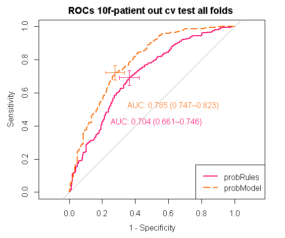

```r
legend("bottomright", legend = c(paste0("probRules"), paste0("probModel")), col = c(colors[15], colors[2]),
    lty = c(1, 5), lwd = 2)
```

```r
thresh = as.numeric(row.names(pModel$best_thr$sensitivity))
confusionMatrix(ifelse(allrulesres[, "probModel"] >= thresh, "C", "NC"), allrulesres[, "obsR"])
```

```
Confusion Matrix and Statistics

          Reference
Prediction   C  NC
        C  143  69
        NC 102 313

               Accuracy : 0.7273
                 95% CI : (0.6906, 0.7618)
    No Information Rate : 0.6093
    P-Value [Acc > NIR] : 3.675e-10

                  Kappa : 0.413
 Mcnemar's Test P-Value : 0.0144

            Sensitivity : 0.5837
            Specificity : 0.8194
         Pos Pred Value : 0.6745
         Neg Pred Value : 0.7542
             Prevalence : 0.3907
         Detection Rate : 0.2281
   Detection Prevalence : 0.3381
      Balanced Accuracy : 0.7015

       'Positive' Class : C
```